# Assigning ASVs with DADA2

Jordan

2025-03-11

# Goals

1. Infer an error model for in the filtered sequences, separately on forward and reverse reads.
2. Assign ASVs on both forward and reverse reads separately by applying the error model.
3. Merge forward and reverse ASVs into “contiguous ASVs”.
4. Generate the first draft of ASV count table.
5. Quality Trimming of ASV lengths.
6. Remove chimeras.
7. Assign Taxonomy with Silva Database.
8. Write out relevant files: `asv_table`, `asvs_fasta`, `tax_table`, and `sample_data`.

## Input

1. Filtered fastq files generated from `01_QualityTrimming.Rmd`.
2. Sample Name vector.

## Output

1. ASV Count Table: `asv_table` (with and without sequence names)
2. ASV fasta file: `asvs_fasta` for building a phylogenetic tree at a later step.
3. Taxonomy Table `tax_table`
4. Sample Information: `sample_data` track the reads lots throughout DADA2 workflow.

# Set up the Environment

## Set Seed & Threads

```r
# Set the seed for reproducibility
set.seed(238428)

# Let's make a parameter to set the number of threads
n_threads = 12
```

## Timing of this script

Let’s record how long this file took to run on the class server, which we will record at the end of the script.

```r
# What time did we start running this script?
start_time <- Sys.time()
```

## Load Packages

```r
# Efficient package loading with pacman
pacman::p_load(tidyverse, devtools, dada2,
               patchwork, DT, install = FALSE)
```

## Load Filtered Fastq Files

```r
# Place filtered seq files into a variable
filtered_fastqs_path <- "data/01_DADA2/02_filtered_fastqs"

# Intuition check:
filtered_fastqs_path
```

```
## [1] "data/01_DADA2/02_filtered_fastqs"
```

```r
# Create Forward vector
filtered_forward_reads <-
  list.files(filtered_fastqs_path, pattern = "R1_filtered.fastq.gz",
             full.names = TRUE)
# Check
filtered_forward_reads[1:5]
```

```
## [1] "data/01_DADA2/02_filtered_fastqs/16S0064C_R1_filtered.fastq.gz"
## [2] "data/01_DADA2/02_filtered_fastqs/16S0064O_R1_filtered.fastq.gz"
## [3] "data/01_DADA2/02_filtered_fastqs/16S0064W_R1_filtered.fastq.gz"
## [4] "data/01_DADA2/02_filtered_fastqs/16S0073C_R1_filtered.fastq.gz"
## [5] "data/01_DADA2/02_filtered_fastqs/16S0073O_R1_filtered.fastq.gz"
```

```r
# Reverse vector
filtered_reverse_reads <-
    list.files(filtered_fastqs_path, pattern = "R2_filtered.fastq.gz",
             full.names = TRUE)

# Check
filtered_reverse_reads[1:5]
```

```
## [1] "data/01_DADA2/02_filtered_fastqs/16S0064C_R2_filtered.fastq.gz"
## [2] "data/01_DADA2/02_filtered_fastqs/16S0064O_R2_filtered.fastq.gz"
## [3] "data/01_DADA2/02_filtered_fastqs/16S0064W_R2_filtered.fastq.gz"
## [4] "data/01_DADA2/02_filtered_fastqs/16S0073C_R2_filtered.fastq.gz"
## [5] "data/01_DADA2/02_filtered_fastqs/16S0073O_R2_filtered.fastq.gz"
```

## Sample Names

```r
# Create vector of sample names from the filenames
sample_names <- sapply(strsplit(basename(filtered_forward_reads), "_"), `[`,1)

# Intuition Check
head(sample_names)
```

```
## [1] "16S0064C" "16S0064O" "16S0064W" "16S0073C" "16S0073O" "16S0073W"
```

# Error Modelling

## How does it work?

This is the step along the workflow where we try to estimate what is a *mistake* from technological sequencing error versus what is *true biological variation*. Therefore, this step is another critical step that we need to be mindful of! This is also what makes DADA2 unique!

Specifically, we will infer error rates for all possible *transitions* within purines and pyrimidines (A<>G or C<>T) and *transversions* between all purine and pyrimidine combinations. The error model is learned by alternating estimation of the error rates and inference of sample composition until they converge. It starts with abundant sequences first and then goes to less abundant sequences. It will:

1. Starts with the assumption that the error rates are the maximum (takes the most abundant sequence (“center”) and assumes it’s the only sequence not caused by errors).
2. Compares the other sequences to the most abundant sequence.
3. Uses at most 10<sup>8</sup> nucleotides for the error estimation. (Though, sometimes we increase this parameter in the case of binned sequencing quality scores.)
4. Uses parametric error estimation function of loess fit on the observed error rates.

## Learn the Errors

### MiSeq Runs: 40 Phred Scores

Here, in the data we have sequenced here, we have Illumina MiSeq data with the traditional 40 Phred scores. Therefore, we can use the traditional `learnErrors()` command, which we will do below.

```r
# Forward Reads
error_forward_reads <-
  learnErrors(filtered_forward_reads, multithread = n_threads)
```

```
## 100991550 total bases in 367242 reads from 4 samples will be used for learning the error rates.
```

```r
# Forward Error Plot
forward_error_plot <-
  plotErrors(error_forward_reads, nominalQ = TRUE) +
  labs(title = "Forward Reads: Error Model")

# Reverse Reads
error_reverse_reads <-
  learnErrors(filtered_reverse_reads, multithread = n_threads)
```

```
## 102285480 total bases in 464934 reads from 5 samples will be used for learning the error rates.
```

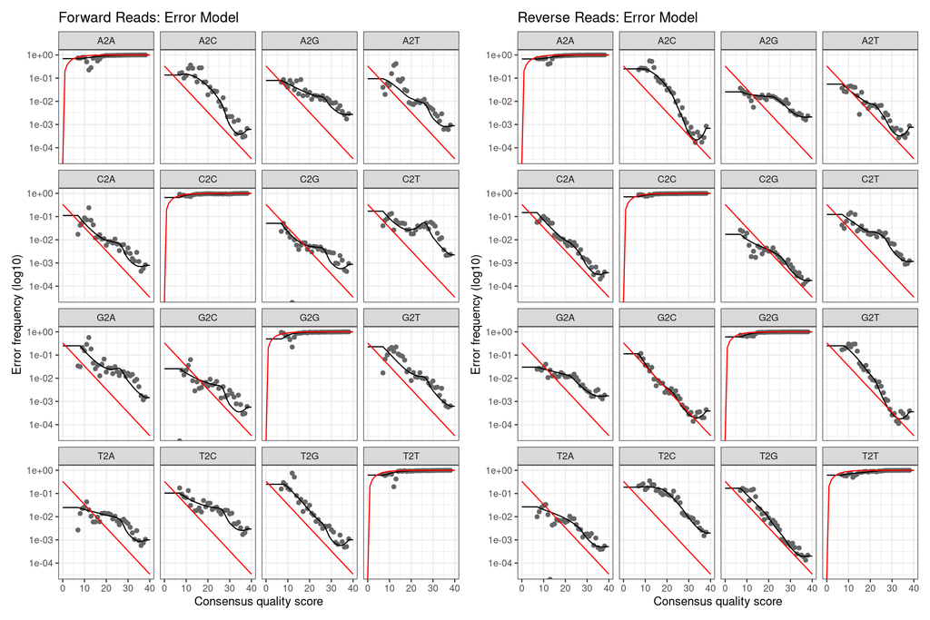

```r
# Reverse Error Plot
reverse_error_plot <-
  plotErrors(error_reverse_reads, nominalQ = TRUE) +
  labs(title = "Reverse Reads: Error Model")

# Look at the plots together
forward_error_plot + reverse_error_plot
```

The above plot represents the error rates for each possible transition (A→C, A→G, …) in the forward reads (on the left) and the reverse reads (on the right).

Details of the plots above: - **Points**: The observed error rates for each consensus quality score.  
- **Black line**: Estimated error rates after convergence of the machine-learning algorithm.  
- **Red line:** The error rates expected under the nominal definition of the Q-score.

Similar to what is mentioned in the [DADA2 tutorial](https://benjjneb.github.io/dada2/tutorial_1_8.html): the estimated error rates (black line) are a “reasonably good” fit to the observed rates (points), and the error rates drop with increased quality as expected. We can now infer ASVs!

# Infer ASVs

```r
# Infer ASVs on the forward sequences
dada_forward <-
  dada(filtered_forward_reads,
       err = error_forward_reads,
       multithread = n_threads)
```

```
## Sample 1 - 113953 reads in 34437 unique sequences.
## Sample 2 - 19 reads in 18 unique sequences.
## Sample 3 - 91937 reads in 26865 unique sequences.
## Sample 4 - 161333 reads in 34413 unique sequences.
## Sample 5 - 97692 reads in 28373 unique sequences.
## Sample 6 - 66539 reads in 22550 unique sequences.
## Sample 7 - 323182 reads in 49399 unique sequences.
## Sample 8 - 127858 reads in 27955 unique sequences.
## Sample 9 - 94011 reads in 18099 unique sequences.
## Sample 10 - 231717 reads in 55590 unique sequences.
## Sample 11 - 185719 reads in 43356 unique sequences.
## Sample 12 - 108275 reads in 22781 unique sequences.
## Sample 13 - 31099 reads in 8868 unique sequences.
## Sample 14 - 32100 reads in 9637 unique sequences.
## Sample 15 - 127100 reads in 19652 unique sequences.
## Sample 16 - 100934 reads in 24753 unique sequences.
## Sample 17 - 33648 reads in 11260 unique sequences.
## Sample 18 - 199117 reads in 50531 unique sequences.
## Sample 19 - 41621 reads in 10991 unique sequences.
## Sample 20 - 42 reads in 40 unique sequences.
## Sample 21 - 106994 reads in 30446 unique sequences.
## Sample 22 - 260678 reads in 55601 unique sequences.
## Sample 23 - 56470 reads in 17364 unique sequences.
## Sample 24 - 99065 reads in 27462 unique sequences.
## Sample 25 - 1350 reads in 460 unique sequences.
## Sample 26 - 1633 reads in 669 unique sequences.
## Sample 27 - 302562 reads in 78343 unique sequences.
## Sample 28 - 99675 reads in 17106 unique sequences.
## Sample 29 - 169084 reads in 39824 unique sequences.
## Sample 30 - 903218 reads in 130343 unique sequences.
## Sample 31 - 27422 reads in 9432 unique sequences.
## Sample 32 - 890 reads in 373 unique sequences.
## Sample 33 - 1770 reads in 617 unique sequences.
## Sample 34 - 5006 reads in 1912 unique sequences.
## Sample 35 - 932231 reads in 197749 unique sequences.
## Sample 36 - 112053 reads in 25163 unique sequences.
## Sample 37 - 90626 reads in 22590 unique sequences.
## Sample 38 - 137445 reads in 41657 unique sequences.
## Sample 39 - 182864 reads in 34750 unique sequences.
## Sample 40 - 107984 reads in 28251 unique sequences.
## Sample 41 - 197874 reads in 59803 unique sequences.
## Sample 42 - 102991 reads in 23283 unique sequences.
## Sample 43 - 106894 reads in 22861 unique sequences.
## Sample 44 - 254578 reads in 69204 unique sequences.
## Sample 45 - 195501 reads in 48809 unique sequences.
## Sample 46 - 111696 reads in 26103 unique sequences.
## Sample 47 - 165022 reads in 40215 unique sequences.
## Sample 48 - 91463 reads in 23605 unique sequences.
## Sample 49 - 221395 reads in 32994 unique sequences.
## Sample 50 - 132768 reads in 34876 unique sequences.
## Sample 51 - 537 reads in 262 unique sequences.
```

```r
# Take a look at the data
# What type of data structure is it?
typeof(dada_forward) # It's a list
```

```
## [1] "list"
```

```r
length(dada_forward) # How big is it? One per sample!
```

```
## [1] 51
```

```r
# What doees it look like for each sample?
dada_forward$`16S0084C_R1_filtered.fastq.gz`
```

```
## dada-class: object describing DADA2 denoising results
## 280 sequence variants were inferred from 18099 input unique sequences.
## Key parameters: OMEGA_A = 1e-40, OMEGA_C = 1e-40, BAND_SIZE = 16
```

```r
# Reverse ASVs
dada_reverse <-
  dada(filtered_reverse_reads,
       err = error_reverse_reads ,
       multithread = n_threads)
```

```
## Sample 1 - 113953 reads in 24986 unique sequences.
## Sample 2 - 19 reads in 17 unique sequences.
## Sample 3 - 91937 reads in 24318 unique sequences.
## Sample 4 - 161333 reads in 28422 unique sequences.
## Sample 5 - 97692 reads in 19685 unique sequences.
## Sample 6 - 66539 reads in 20460 unique sequences.
## Sample 7 - 323182 reads in 38383 unique sequences.
## Sample 8 - 127858 reads in 22602 unique sequences.
## Sample 9 - 94011 reads in 13914 unique sequences.
## Sample 10 - 231717 reads in 43301 unique sequences.
## Sample 11 - 185719 reads in 31848 unique sequences.
## Sample 12 - 108275 reads in 20532 unique sequences.
## Sample 13 - 31099 reads in 7581 unique sequences.
## Sample 14 - 32100 reads in 7947 unique sequences.
## Sample 15 - 127100 reads in 17861 unique sequences.
## Sample 16 - 100934 reads in 20718 unique sequences.
## Sample 17 - 33648 reads in 9742 unique sequences.
## Sample 18 - 199117 reads in 42254 unique sequences.
## Sample 19 - 41621 reads in 9064 unique sequences.
## Sample 20 - 42 reads in 40 unique sequences.
## Sample 21 - 106994 reads in 25708 unique sequences.
## Sample 22 - 260678 reads in 42521 unique sequences.
## Sample 23 - 56470 reads in 15408 unique sequences.
## Sample 24 - 99065 reads in 22777 unique sequences.
## Sample 25 - 1350 reads in 433 unique sequences.
## Sample 26 - 1633 reads in 644 unique sequences.
## Sample 27 - 302562 reads in 49897 unique sequences.
## Sample 28 - 99675 reads in 12273 unique sequences.
## Sample 29 - 169084 reads in 33043 unique sequences.
## Sample 30 - 903218 reads in 85295 unique sequences.
## Sample 31 - 27422 reads in 7929 unique sequences.
## Sample 32 - 890 reads in 322 unique sequences.
## Sample 33 - 1770 reads in 570 unique sequences.
## Sample 34 - 5006 reads in 1815 unique sequences.
## Sample 35 - 932231 reads in 156484 unique sequences.
## Sample 36 - 112053 reads in 19232 unique sequences.
## Sample 37 - 90626 reads in 17914 unique sequences.
## Sample 38 - 137445 reads in 33665 unique sequences.
## Sample 39 - 182864 reads in 26289 unique sequences.
## Sample 40 - 107984 reads in 23773 unique sequences.
## Sample 41 - 197874 reads in 44810 unique sequences.
## Sample 42 - 102991 reads in 18410 unique sequences.
## Sample 43 - 106894 reads in 18368 unique sequences.
## Sample 44 - 254578 reads in 57146 unique sequences.
## Sample 45 - 195501 reads in 40563 unique sequences.
## Sample 46 - 111696 reads in 21385 unique sequences.
## Sample 47 - 165022 reads in 29183 unique sequences.
## Sample 48 - 91463 reads in 18926 unique sequences.
## Sample 49 - 221395 reads in 27148 unique sequences.
## Sample 50 - 132768 reads in 25256 unique sequences.
## Sample 51 - 537 reads in 255 unique sequences.
```

```r
# Check data
dada_reverse[30]
```

```
## $`16S0117W_R2_filtered.fastq.gz`
## dada-class: object describing DADA2 denoising results
## 1267 sequence variants were inferred from 85295 input unique sequences.
## Key parameters: OMEGA_A = 1e-40, OMEGA_C = 1e-40, BAND_SIZE = 16
```

# Merge Forward and Reverse ASVs

Now, that we have identified our ASVs separately on both the forward and the reverse reads, let’s **merge** them together into contiguous (*aka* “contigs”) ASVs.

```r
merged_ASVs <-
  mergePairs(dada_forward, filtered_forward_reads,
             dada_reverse, filtered_reverse_reads,
             verbose = TRUE)
```

```
## 102977 paired-reads (in 1298 unique pairings) successfully merged out of 108790 (in 4688 pairings) input.
```

```
## 2 paired-reads (in 1 unique pairings) successfully merged out of 2 (in 1 pairings) input.
```

```
## 85693 paired-reads (in 1335 unique pairings) successfully merged out of 88036 (in 2222 pairings) input.
```

```
## 157384 paired-reads (in 692 unique pairings) successfully merged out of 159280 (in 1636 pairings) input.
```

```
## 92746 paired-reads (in 731 unique pairings) successfully merged out of 95758 (in 2212 pairings) input.
```

```
## 61872 paired-reads (in 1099 unique pairings) successfully merged out of 63239 (in 1564 pairings) input.
```

```
## 318379 paired-reads (in 733 unique pairings) successfully merged out of 321505 (in 1569 pairings) input.
```

```
## 123988 paired-reads (in 781 unique pairings) successfully merged out of 126566 (in 1927 pairings) input.
```

```
## 92196 paired-reads (in 338 unique pairings) successfully merged out of 93030 (in 799 pairings) input.
```

```
## 224573 paired-reads (in 1189 unique pairings) successfully merged out of 228489 (in 2727 pairings) input.
```

```
## 178778 paired-reads (in 1366 unique pairings) successfully merged out of 182825 (in 3260 pairings) input.
```

```
## 107348 paired-reads (in 260 unique pairings) successfully merged out of 107797 (in 429 pairings) input.
```

```
## 30058 paired-reads (in 331 unique pairings) successfully merged out of 30412 (in 444 pairings) input.
```

```
## 31067 paired-reads (in 330 unique pairings) successfully merged out of 31613 (in 481 pairings) input.
```

```
## 125197 paired-reads (in 346 unique pairings) successfully merged out of 126280 (in 847 pairings) input.
```

```
## 99856 paired-reads (in 408 unique pairings) successfully merged out of 100284 (in 621 pairings) input.
```

```
## 32161 paired-reads (in 409 unique pairings) successfully merged out of 32959 (in 646 pairings) input.
```

```
## 192588 paired-reads (in 931 unique pairings) successfully merged out of 196473 (in 2863 pairings) input.
```

```
## 40777 paired-reads (in 202 unique pairings) successfully merged out of 41236 (in 321 pairings) input.
```

```
## 6 paired-reads (in 2 unique pairings) successfully merged out of 6 (in 2 pairings) input.
```

```
## 103332 paired-reads (in 647 unique pairings) successfully merged out of 105434 (in 1756 pairings) input.
```

```
## 255960 paired-reads (in 1114 unique pairings) successfully merged out of 258521 (in 2089 pairings) input.
```

```
## 53225 paired-reads (in 801 unique pairings) successfully merged out of 54214 (in 1089 pairings) input.
```

```
## 93921 paired-reads (in 732 unique pairings) successfully merged out of 97264 (in 2609 pairings) input.
```

```
## 1298 paired-reads (in 24 unique pairings) successfully merged out of 1309 (in 27 pairings) input.
```

```
## 1490 paired-reads (in 63 unique pairings) successfully merged out of 1517 (in 69 pairings) input.
```

```
## 284480 paired-reads (in 2881 unique pairings) successfully merged out of 296495 (in 8423 pairings) input.
```

```
## 98968 paired-reads (in 148 unique pairings) successfully merged out of 99229 (in 224 pairings) input.
```

```
## 164126 paired-reads (in 801 unique pairings) successfully merged out of 166783 (in 2284 pairings) input.
```

```
## 880555 paired-reads (in 4895 unique pairings) successfully merged out of 896608 (in 11530 pairings) input.
```

```
## 26764 paired-reads (in 359 unique pairings) successfully merged out of 27000 (in 420 pairings) input.
```

```
## 841 paired-reads (in 20 unique pairings) successfully merged out of 842 (in 21 pairings) input.
```

```
## 1652 paired-reads (in 28 unique pairings) successfully merged out of 1673 (in 33 pairings) input.
```

```
## 4720 paired-reads (in 124 unique pairings) successfully merged out of 4850 (in 158 pairings) input.
```

```
## 901754 paired-reads (in 3623 unique pairings) successfully merged out of 920391 (in 13574 pairings) input.
```

```
## 107450 paired-reads (in 592 unique pairings) successfully merged out of 109387 (in 1373 pairings) input.
```

```
## 86370 paired-reads (in 629 unique pairings) successfully merged out of 88563 (in 1689 pairings) input.
```

```
## 128893 paired-reads (in 948 unique pairings) successfully merged out of 134045 (in 3535 pairings) input.
```

```
## 178458 paired-reads (in 778 unique pairings) successfully merged out of 180373 (in 1633 pairings) input.
```

```
## 103997 paired-reads (in 647 unique pairings) successfully merged out of 106166 (in 1731 pairings) input.
```

```
## 182495 paired-reads (in 1517 unique pairings) successfully merged out of 192223 (in 7113 pairings) input.
```

```
## 99283 paired-reads (in 481 unique pairings) successfully merged out of 100822 (in 1062 pairings) input.
```

```
## 103913 paired-reads (in 387 unique pairings) successfully merged out of 105446 (in 1025 pairings) input.
```

```
## 244835 paired-reads (in 1611 unique pairings) successfully merged out of 250387 (in 4436 pairings) input.
```

```
## 190375 paired-reads (in 855 unique pairings) successfully merged out of 193221 (in 2401 pairings) input.
```

```
## 107255 paired-reads (in 825 unique pairings) successfully merged out of 109964 (in 2457 pairings) input.
```

```
## 157098 paired-reads (in 1137 unique pairings) successfully merged out of 161979 (in 3645 pairings) input.
```

```
## 89215 paired-reads (in 511 unique pairings) successfully merged out of 90390 (in 1036 pairings) input.
```

```
## 218432 paired-reads (in 645 unique pairings) successfully merged out of 220173 (in 1344 pairings) input.
```

```
## 125717 paired-reads (in 910 unique pairings) successfully merged out of 130507 (in 3194 pairings) input.
```

```
## 449 paired-reads (in 26 unique pairings) successfully merged out of 476 (in 29 pairings) input.
```

```r
# Evaluate the data output
typeof(merged_ASVs) # A list
```

```
## [1] "list"
```

```r
length(merged_ASVs) # Length of the number of samples!
```

```
## [1] 51
```

```r
head(names(merged_ASVs)) # Here, we can access our current sample names
```

```
## [1] "16S0064C_R1_filtered.fastq.gz" "16S0064O_R1_filtered.fastq.gz"
## [3] "16S0064W_R1_filtered.fastq.gz" "16S0073C_R1_filtered.fastq.gz"
## [5] "16S0073O_R1_filtered.fastq.gz" "16S0073W_R1_filtered.fastq.gz"
```

```r
# Inspect further for each sample
#head(merged_ASVs, n = 2) # A dataframe for each sample
# We have a dataframe in each part of our list! What are in the columns?
glimpse(merged_ASVs$`16S0084C_R1_filtered.fastq.gz`)
```

```
## Rows: 338
## Columns: 9
## $ sequence  <chr> "TGAGGAATATTGGACAATGGGTGGAAGCCTGATCCAGCCATCCCGCGTGCAGGAAGACG…
## $ abundance <int> 24063, 15849, 7131, 4010, 3651, 3598, 3490, 3234, 2887, 1949…
## $ forward   <int> 1, 2, 3, 4, 6, 9, 5, 8, 7, 10, 11, 13, 12, 1, 14, 15, 16, 17…
## $ reverse   <int> 1, 2, 3, 5, 6, 7, 4, 8, 4, 9, 10, 11, 13, 4, 12, 14, 16, 18,…
## $ nmatch    <int> 73, 69, 93, 68, 73, 71, 73, 68, 73, 68, 68, 90, 68, 73, 68, …
## $ nmismatch <int> 0, 0, 0, 0, 0, 0, 0, 0, 0, 0, 0, 0, 0, 0, 0, 0, 0, 0, 0, 0, …
## $ nindel    <int> 0, 0, 0, 0, 0, 0, 0, 0, 0, 0, 0, 0, 0, 0, 0, 0, 0, 0, 0, 0, …
## $ prefer    <dbl> 2, 2, 2, 2, 2, 2, 2, 2, 2, 2, 2, 2, 1, 1, 2, 2, 2, 2, 1, 1, …
## $ accept    <lgl> TRUE, TRUE, TRUE, TRUE, TRUE, TRUE, TRUE, TRUE, TRUE, TRUE, …
```

# Create Raw ASV Count Table

```r
# Raw ASV
raw_ASV_table <- makeSequenceTable(merged_ASVs)

# Intuition Check: Type and dimensions of the data
dim(raw_ASV_table)
```

```
## [1]    51 27558
```

```r
typeof(raw_ASV_table)
```

```
## [1] "integer"
```

```r
class(raw_ASV_table)
```

```
## [1] "matrix" "array"
```

```r
# write out raw_asv_table
write.table(raw_ASV_table, file = "data/01_DADA2/raw_ASV_counts.tsv",
            sep = "\t", quote = FALSE, col.names = NA)
```

# Assess ASV Quality

## What are the current ASV lengths?

First, let’s inspect the distribution of the ASV sequence lengths across all of the ASVs that we have inferred. First, we need to consider: **What is the expected length of the ASVs?**

1. *What is the sequencing strategy?*
   - paired-end 300bp (2x300bp) Illumina MiSeq Sequencing was used.
   - Specifically, the V3-4 hypervariable region of the 16S rRNA gene was targeted for sequencing with the 341F and 805R primers.
2. *What’s the total length of our starting amplicons?*
   - Our primers are named after the location they bind to on the 16S gene. So:
   - `805 - 341 = 464`
   - The total length of the starting amplicon is 464 base pairs, with primers.
3. *What is the ASV length without primers?*
   - The 341F (`CCTACGGGNGGCWGCAG`) primer is 17 base pairs.
   - The 805R (`GACTACHVGGGTATCTAATCC`) primer is 21 base pairs.
   - `464 - 17 - 21 = 426`
   - The expected ASV length without primers is **426 base pairs**.
4. *What is the length of the trimmed ASVs after `filterAndTrim()`?*
   - In our `01_QualityTrimming.Rmd`, we used `truncLen = c(275, 220)`, which removed 25 bases at the ends of the forward reads, and removed 80 bases at the end of the reverse read. Therefore:
   - `426 - 25 = 401`
   - `426 - 80 = 346`
5. *What is the overlap between our forward and reverse reads?*
   - We performed 2x300 paired-end Illumina MiSeq Sequencing. However, from our multiQC report, we can see that our read length is actually just less than 300 bp.
   - If we have a total read length of 300 base pairs and **we did not sequence our primers** (non-biological sequences trimmed by sequencing facility), then our overlap should be 69bp (with 275bp forward and 220bp reverse reads).

### ASV Length Stats

```r
# Calculate summary stats
# Longest ASV?
maxLength_ASV <- max(nchar(getSequences(raw_ASV_table)))

# Shortest ASV?
minLength_ASV <- min(nchar(getSequences(raw_ASV_table)))

# Mean ASV length?
meanLength_ASV <- mean(nchar(getSequences(raw_ASV_table)))

# Median ASV length?
medianLength_ASV <- median(nchar(getSequences(raw_ASV_table)))

# Create a table to Inspect the distribution of sequence lengths of all ASVs in dataset
table(nchar(getSequences(raw_ASV_table)))
```

```
##
##  275  352  367  373  382  383  384  385  386  387  394  399  400  401  402  403
##  200    1    3    1    1    4    8   34   11    7    1    2   38  163 4384  446
##  404  405  406  407  408  409  410  411  413  414  415  416  417  418  419  420
##  424  362  262   98   50   53   55    8    7   37   16   44   25    7   36  105
##  421  422  423  424  425  426  427  428  429  430  450  453
##  382 7311  442  185   40  589 9580 2045   79   10    1    1
```

In the table above, we can see that we actually have quite the ASV sequence length distribution! There are some longer ASVs that are clearly spurious… we need to be **skeptical**! We see that the most abundant ASV length is 427, which has ~2000 more ASVs than compared to the other most abundant length (422). SI think I will keep a range of ASVs from 422 to 427.

Here’s some of the stats that we’ve calculated:

- Max ASV length: 453 base pairs
- Min ASV length: 275 base pairs
- Mean ASV length: 418.6763553 base pairs
- Median ASV length: 422 base pairs

However, the median length actually is about what we are expecting, which is great. *Let’s take a look at what this looks like graphically!*

### ASV Length Plot

Now, we will plot these ASV lengths to give us a better idea:

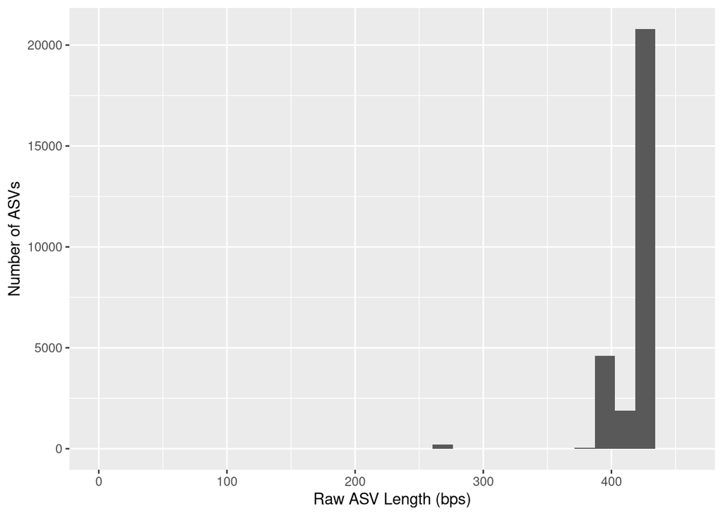

```r
# Inspect the distribution of sequence lengths of all ASVs in data set
# AFTER TRIM
plot_ASVLength_raw <-
  data.frame(Seq_Length = nchar(getSequences(raw_ASV_table))) %>%
  ggplot(aes(x = Seq_Length )) +
  geom_histogram() +
  # include the x-axis scales
  scale_x_continuous(limits = c(0, maxLength_ASV + 5)) +
  labs(y = "Number of ASVs", x = "Raw ASV Length (bps)")

# Show the plot
plot_ASVLength_raw
```

As we saw in the table, the length of the ASVs is mostly 427 base pairs.

My ASV length data pretty much matched my hypothesis. I calculated it would be 426 bp without the primers, and from the table and graph we see the most abundant length is 427. This is only off by 1bp, but the in-class data was also off by 1bp, so I am assuming this is ok.

Taking my interpretations into account, my trimming procedure is to take lengths 422-427bp.

## Trim ASV lengths

**NOTE:** This is another moment in our workflow where we are sub-setting only the “good parts” of our data to ensure the data quality we have at the end is the best of our ability based on the sequencing run.

```r
# Subset only ASVs that are 245 bps long
raw_ASV_table_trimmed <-
  raw_ASV_table[, nchar(colnames(raw_ASV_table)) >= 422 & nchar(colnames(raw_ASV_table)) <= 427]

# Inspect the distribution of sequence lengths of all ASVs in dataset
table(nchar(getSequences(raw_ASV_table_trimmed)))
```

```
##
##  422  423  424  425  426  427
## 7311  442  185   40  589 9580
```

```r
# What proportion of total ASV sequences are left in the data?
percRetained_Trimmed <- sum(raw_ASV_table_trimmed)/sum(raw_ASV_table)
percRetained_Trimmed # Show it
```

```
## [1] 0.7120813
```

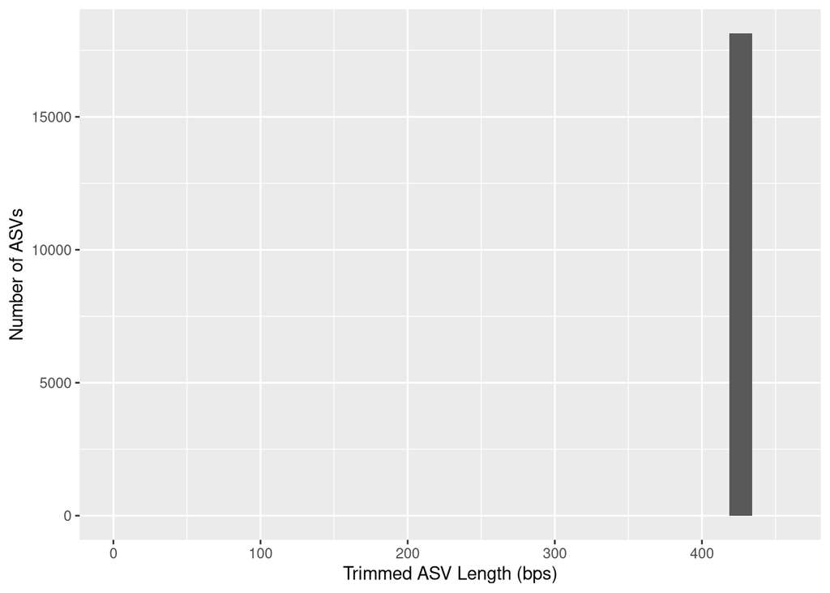

```r
# Inspect the distribution of sequence lengths of all ASVs in dataset
# AFTER TRIM
plot_ASVLength_trimmed <-
  data.frame(Seq_Length = nchar(getSequences(raw_ASV_table_trimmed))) %>%
  ggplot(aes(x = Seq_Length )) +
  geom_histogram() +
  # include the x-axis scales
  scale_x_continuous(limits = c(0, maxLength_ASV + 5)) +
  labs(y = "Number of ASVs", x = "Trimmed ASV Length (bps)")

# Show the plot
plot_ASVLength_trimmed
```

# Remove Chimeras

```r
# Remove the chimeras in the raw ASV table
noChimeras_ASV_table <-
  removeBimeraDenovo(raw_ASV_table_trimmed,
                     method="consensus",
                     multithread = n_threads,
                     verbose=TRUE)
```

```
## Identified 11502 bimeras out of 18147 input sequences.
```

```r
# Check the dimensions
dim(noChimeras_ASV_table)
```

```
## [1]   51 6645
```

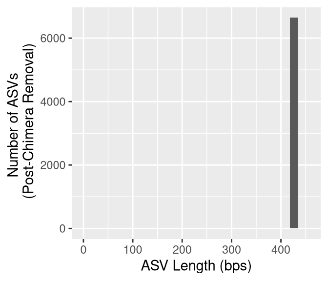

```r
# What proportion is left of the sequences?
# Chimera removal compared to trimming
percRetained_chimerasTrimmed <- sum(noChimeras_ASV_table)/sum(raw_ASV_table_trimmed)
# Chimera removal compared to raw
percRetained_chimerasRaw <-sum(noChimeras_ASV_table)/sum(raw_ASV_table)

# Plot it
plot_ASVLength_NoChimeras <-
  data.frame(Seq_Length_NoChim = nchar(getSequences(noChimeras_ASV_table))) %>%
  ggplot(aes(x = Seq_Length_NoChim )) +
  geom_histogram()+
  # include the x-axis scales
  scale_x_continuous(limits = c(0, maxLength_ASV + 5)) +
  labs(y = "Number of ASVs \n (Post-Chimera Removal)",
       x = "ASV Length (bps)")

# Show the plot
plot_ASVLength_NoChimeras
```

**Note the peak at 427 is now wayyy below 15,000 ASVs!** So, we have removed 11502 ASVs, which were chimeras. Let’s review what proportion of ASVs we have retained along the workflow:

1. 71.21% of the raw ASVs were retained *after trimming*.
2. 95.25% of the trimmed ASV counts were retained *after chimera removal*.
3. This translates to 67.82% retention of the original, raw merged ASV counts after *both trimming and chimera removal.*

So, there is ok retention of the ASVs after length trimming and chimera removal. I still think the ASV lengths have been trimmed appropriately since there are still many ASVs and the plots of number of sequences and number of ASVs look similar / have similar distributions.

### Plot ASV Lengths

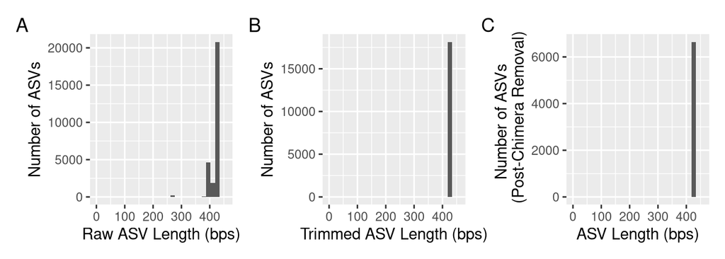

```r
plot_ASVLength_raw + plot_ASVLength_trimmed + plot_ASVLength_NoChimeras +
    plot_annotation(tag_levels = 'A')
```

# Track the read counts

Here, we will look at the number of reads that were lost in the filtering, denoising, merging, and chimera removal.

```r
# A little function to identify number seqs
getN <- function(x) sum(getUniques(x))

# Make the table to track the seqs
track <- cbind(sapply(dada_forward, getN),
               sapply(dada_reverse, getN),
               sapply(merged_ASVs, getN),
               rowSums(noChimeras_ASV_table))

head(track)
```

```
##                                 [,1]   [,2]   [,3]   [,4]
## 16S0064C_R1_filtered.fastq.gz 109718 112557 102977  66771
## 16S0064O_R1_filtered.fastq.gz      2      4      2      2
## 16S0064W_R1_filtered.fastq.gz  88900  89691  85693  63232
## 16S0073C_R1_filtered.fastq.gz 159802 160659 157384 107288
## 16S0073O_R1_filtered.fastq.gz  96163  97136  92746  73242
## 16S0073W_R1_filtered.fastq.gz  64076  64540  61872  29762
```

```r
# Update column names to be more informative (most are missing at the moment!)
colnames(track) <- c("denoisedF", "denoisedR", "merged", "nochim")
rownames(track) <- row.names(noChimeras_ASV_table)

# Generate a dataframe to track the reads through our DADA2 pipeline
track_counts_df <-
  track %>%
  # make it a dataframe
  as.data.frame() %>%
  rownames_to_column(var = "sample_names")

# Now let's add a column for the number of ASVs
# First, intuition check that the samples match
stopifnot(track_counts_df$sample_names == row.names(noChimeras_ASV_table))

# Now, let's add a new column with the number of ASVs
track_counts_df <-
  track_counts_df %>%
  mutate(num_ASVs = rowSums(noChimeras_ASV_table > 1))

# Visualize it in table format
DT::datatable(track_counts_df)
```

|  | sample_names | denoisedF | denoisedR | merged | nochim | num_ASVs |
| --- | --- | --- | --- | --- | --- | --- |
| 1 | 16S0064C_R1_filtered.fastq.gz | 109718 | 112557 | 102977 | 66771 | 360 |
| 2 | 16S0064O_R1_filtered.fastq.gz | 2 | 4 | 2 | 2 | 1 |
| 3 | 16S0064W_R1_filtered.fastq.gz | 88900 | 89691 | 85693 | 63232 | 599 |
| 4 | 16S0073C_R1_filtered.fastq.gz | 159802 | 160659 | 157384 | 107288 | 220 |
| 5 | 16S0073O_R1_filtered.fastq.gz | 96163 | 97136 | 92746 | 73242 | 279 |
| 6 | 16S0073W_R1_filtered.fastq.gz | 64076 | 64540 | 61872 | 29762 | 498 |
| 7 | 16S0074C_R1_filtered.fastq.gz | 322121 | 322446 | 318379 | 230726 | 143 |
| 8 | 16S0074O_R1_filtered.fastq.gz | 126807 | 127449 | 123988 | 98199 | 215 |
| 9 | 16S0084C_R1_filtered.fastq.gz | 93295 | 93631 | 92196 | 74898 | 110 |
| 10 | 16S0084W_R1_filtered.fastq.gz | 229281 | 230310 | 224573 | 168167 | 581 |

[output cut: 41 more lines]

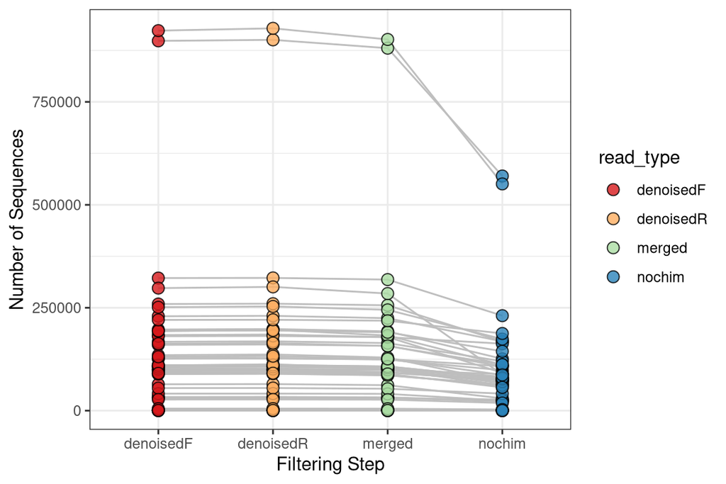

```r
# Plot it!
track_counts_df %>%
  pivot_longer(denoisedF:nochim, names_to = "read_type", values_to = "num_reads") %>%
  mutate(read_type = fct_relevel(read_type, "denoisedF", "denoisedR", "merged", "nochim")) %>%
  ggplot(aes(x = read_type, y = num_reads, fill = read_type)) +
  geom_line(aes(group = sample_names), color = "grey") +
  geom_point(shape = 21, size = 3, alpha = 0.8) +
  scale_fill_brewer(palette = "Spectral") +
  labs(x = "Filtering Step", y = "Number of Sequences") +
  theme_bw()
```

Now, let’s plot the number of sequences that have been maintained in our samples using `geom_histogram()`.

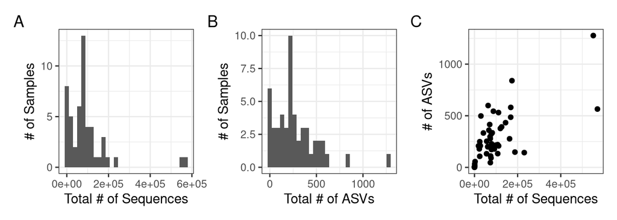

```r
plot_ReadDepth <-
  track_counts_df %>%
  ggplot(aes(x = nochim)) +
  geom_histogram() +
  labs(x = "Total # of Sequences", y = "# of Samples") +
  theme_bw()

# What is the ASV richness per sample?
plot_ASVRichness <-
  track_counts_df %>%
  ggplot(aes(x = num_ASVs)) +
  geom_histogram() +
  labs(x = "Total # of ASVs", y = "# of Samples") +
  theme_bw()

# Now, let's look at the relationship of ASVs and Sequencing depth
plot_ReadDepth_ASVRichness <-
  track_counts_df %>%
  ggplot(aes(x = nochim, y = num_ASVs)) +
  geom_point() +
  labs(x = "Total # of Sequences", y = "# of ASVs") +
  theme_bw()

# Show the plots together
plot_ReadDepth + plot_ASVRichness + plot_ReadDepth_ASVRichness +
    plot_annotation(tag_levels = 'A')
```

The figure above consists of three plots that summarize sequencing depth, ASV richness, and their relationship after DADA2 processing of 16S rRNA gene sequencing data.

**Panel A: Read Depth after DADA2:** Histogram of sequencing depth per sample (Total # of Sequences)

- Disregarding the 2 outliers, the distribution is roughly unimodal, centered around 100,000 reads per sample.
- Some samples have very low read counts (~0 reads)
- A couple of other samples have higher sequencing depth (550,000 reads).

**Panel B: ASV Richness after DADA2:** Histogram of ASV richness (Total # of ASVs per sample)

- Most samples have ~250 ASVs, and follow a similar unimodal distribution as sequencing depth, disregarding outliers.
- Some samples have very low ASV counts (< 50). *Perhaps this corresponds to low read depth?*
- A couple samples have higher ASV counts (~1000). These are probably the samples with more sequences.

**Panel C: Read Depth vs ASV Richness:** Scatter plot showing the relationship between sequencing depth and ASV richness.

- Generally there might be a positive correlation, where samples with higher read depth tend to have more ASVs. This helps show the importance of rarefaction!

**Overall Interpretation & Considerations**

1. *Sequencing depth variation*: Most samples cluster around a common sequencing depth, but ~ 8 samples are definitely under-sequenced.
2. *ASV richness follows read depth trends*: Low sequencing depth samples have lower ASV richness, potentially biasing ecological interpretations.
3. *Rarefaction or normalization may be needed*: The right plot suggests that richness estimates are influenced by read depth, so rarefying or using appropriate statistical corrections will be necessary for comparative analysis.

# Assign Taxonomy

Here, we will use the **silva database version 138.2**, which has been properly formatted for DADA2. The files came from this [DADA2-formatted reference databases website](https://benjjneb.github.io/dada2/training.html), which hosts several other reference taxomoy files for several popular taxonomic databases.

In this example, we are going to use the database that is pre-downloaded to the server at the following path: `/workdir/in_class_data/taxonomy/`. You are welcome to symbolically link the taxonomy files, however note that they are VERY LARGE. So, it is actually suggested here (for this one time) to use the absolute path here. However, we need to note that this would break our reproducibility!

## How does the taxonomy work?

The `assignTaxonomy` function implements the Ribosomal Database Project (RDP) Naive Bayesian Classifier algorithm described in Wang et al. (2007), published in Applied and Environmental Microbiology, with a kmer size of 8 and 100 bootstrap replicates.

```r
# Assign up to genus level
taxa_train <-
  assignTaxonomy(noChimeras_ASV_table,
                 refFasta = "/workdir/in_class_data/taxonomy/silva_nr99_v138.2_toGenus_trainset.fa.gz",
                 multithread = n_threads)

# Add the genus/species information
taxa_addSpecies <-
  addSpecies(taxa_train,
              refFasta = "/workdir/in_class_data/taxonomy/silva_v138.2_assignSpecies.fa.gz")

# Inspect the taxonomy
glimpse(taxa_addSpecies) # Note that the rownames are the ASV sequences!
```

```
##  chr [1:6645, 1:7] "Bacteria" "Bacteria" "Bacteria" "Bacteria" "Bacteria" ...
##  - attr(*, "dimnames")=List of 2
##   ..$ : chr [1:6645] "TGAGGAATATTGGACAATGGGCGAGAGCCTGATCCAGCCATGCCGCGTGCAGGAAGACTGCCCTATGGGTTGTAAACTGCTTTTATACAGGAAGAATAAGCCTTACGTGTA"| __truncated__ "TGAGGAATATTGGACAATGGGTGGAAGCCTGATCCAGCCATCCCGCGTGCAGGAAGACGGCCCTATGGGTTGTAAACTGCTTTTATACAGGAATAAATCTATCTACGAGTA"| __truncated__ "TGGGGAATATTGCACAA…
##   ..$ : chr [1:7] "Kingdom" "Phylum" "Class" "Order" ...
```

```r
# Let's removing the ASV sequence rownames for display only
taxa_print <- taxa_addSpecies
rownames(taxa_print) <- NULL
head(taxa_print)
```

```
##      Kingdom    Phylum           Class                 Order
## [1,] "Bacteria" "Bacteroidota"   "Bacteroidia"         "Flavobacteriales"
## [2,] "Bacteria" "Bacteroidota"   "Bacteroidia"         "Flavobacteriales"
## [3,] "Bacteria" "Pseudomonadota" "Gammaproteobacteria" "Enterobacterales"
## [4,] "Bacteria" "Bacteroidota"   "Bacteroidia"         "Flavobacteriales"
## [5,] "Bacteria" "Pseudomonadota" "Gammaproteobacteria" "Enterobacterales"
## [6,] "Bacteria" "Pseudomonadota" "Gammaproteobacteria" "Enterobacterales"
##      Family              Genus               Species
## [1,] "Flavobacteriaceae" "NS3a marine group" NA
## [2,] "Weeksellaceae"     "Ornithobacterium"  NA
## [3,] "Shewanellaceae"    "Shewanella"        NA
## [4,] "Flavobacteriaceae" "NS3a marine group" NA
## [5,] "Vibrionaceae"      "Catenococcus"      NA
## [6,] "Vibrionaceae"      "Vibrio"            NA
```

```r
#View(taxa_print)
```

# Export the Data

Remember from the beginning of the file under “Goals”, we wanted to export 4 different types of information:

1. ASV Count Table: `asv_table` (with and without sequence names)
2. ASV fasta file: `asvs_fasta` for building a phylogenetic tree at a later step.
3. Taxonomy Table `tax_table`
4. Sample Information: `sample_data` track the reads lots throughout DADA2 workflow.

## 1. ASV Tables

We will export the following two ASV count tables, which will be in “long” format where the **ASVs are in rows** and the **sample names are in the columns.**

Let’s check that the ASVs are in the rows and the sample names are in the columns. If not, we can use the transpose function `t()` in R.

```r
# What's the current format of the ASV table?
head(rownames(noChimeras_ASV_table)) # Samples!
```

```
## [1] "16S0064C_R1_filtered.fastq.gz" "16S0064O_R1_filtered.fastq.gz"
## [3] "16S0064W_R1_filtered.fastq.gz" "16S0073C_R1_filtered.fastq.gz"
## [5] "16S0073O_R1_filtered.fastq.gz" "16S0073W_R1_filtered.fastq.gz"
```

```r
head(colnames(noChimeras_ASV_table)) # ASV Sequences
```

```
## [1] "TGAGGAATATTGGACAATGGGCGAGAGCCTGATCCAGCCATGCCGCGTGCAGGAAGACTG…"
## [2] "TGAGGAATATTGGACAATGGGTGGAAGCCTGATCCAGCCATCCCGCGTGCAGGAAGACGG…"
## [3] "TGGGGAATATTGCACAATGGGGGAAACCCTGATGCAGCCATGCCGCGTGTGTGAAGAAGG…"
## [4] "TGAGGAATATTGGACAATGGGCGGGAGCCTGATCCAGCCATGCCGCGTGCAGGAAGACTG…"
## [5] "TGGGGAATATTGCACAATGGGCGCAAGCCTGATGCAGCCATGCCGCGTGTGTGAAGAAGG…"
## [6] "TGGGGAATATTGCACAATGGGCGCAAGCCTGATGCAGCCATGCCGCGTGTATGAAGAAGG…"
```

```r
# Therefore, we need to transpose the matrix
final_ASV_table_withSeqs <- t(noChimeras_ASV_table)

# Intuition check
head(rownames(final_ASV_table_withSeqs)) # ASV Sequences
```

```
## [1] "TGAGGAATATTGGACAATGGGCGAGAGCCTGATCCAGCCATGCCGCGTGCAGGAAGACTG…"
## [2] "TGAGGAATATTGGACAATGGGTGGAAGCCTGATCCAGCCATCCCGCGTGCAGGAAGACGG…"
## [3] "TGGGGAATATTGCACAATGGGGGAAACCCTGATGCAGCCATGCCGCGTGTGTGAAGAAGG…"
## [4] "TGAGGAATATTGGACAATGGGCGGGAGCCTGATCCAGCCATGCCGCGTGCAGGAAGACTG…"
## [5] "TGGGGAATATTGCACAATGGGCGCAAGCCTGATGCAGCCATGCCGCGTGTGTGAAGAAGG…"
## [6] "TGGGGAATATTGCACAATGGGCGCAAGCCTGATGCAGCCATGCCGCGTGTATGAAGAAGG…"
```

```r
head(colnames(final_ASV_table_withSeqs)) # Sample names
```

```
## [1] "16S0064C_R1_filtered.fastq.gz" "16S0064O_R1_filtered.fastq.gz"
## [3] "16S0064W_R1_filtered.fastq.gz" "16S0073C_R1_filtered.fastq.gz"
## [5] "16S0073O_R1_filtered.fastq.gz" "16S0073W_R1_filtered.fastq.gz"
```

### Names in ASV tables

#### Fix Sample Names

Notice above that the sample names are actually file names. Let’s fix this!

> WARNING! This is an easy place where a silent error can step in where we could misname our samples, leading to catastrophe down the road. So, we need to be very careful and complete our checks and balances so we ensure the samples are not mixed up in the renaming process.

```r
# Remember at the top of the file we created a vector of sample names
head(sample_names)
```

```
## [1] "16S0064C" "16S0064O" "16S0064W" "16S0073C" "16S0073O" "16S0073W"
```

```r
# Let's check with the actual column names
head(colnames(final_ASV_table_withSeqs)) # Sample names
```

```
## [1] "16S0064C_R1_filtered.fastq.gz" "16S0064O_R1_filtered.fastq.gz"
## [3] "16S0064W_R1_filtered.fastq.gz" "16S0073C_R1_filtered.fastq.gz"
## [5] "16S0073O_R1_filtered.fastq.gz" "16S0073W_R1_filtered.fastq.gz"
```

```r
# And then apply our sample name script to check, too
head(sapply(strsplit(colnames(final_ASV_table_withSeqs), "_"), `[`,1)) # Looks good!
```

```
## [1] "16S0064C" "16S0064O" "16S0064W" "16S0073C" "16S0073O" "16S0073W"
```

```r
# Now, add a break in the script break if this isn't true!
# Let's make sure the sample names match the file names in the matrix.
stopifnot(sapply(strsplit(colnames(final_ASV_table_withSeqs), "_"), `[`,1) == sample_names)

# Now, we've done some checks to prove to ourselves there will be no silent errors,
# Let's rename!
colnames(final_ASV_table_withSeqs) <- sample_names
head(colnames(final_ASV_table_withSeqs))
```

```
## [1] "16S0064C" "16S0064O" "16S0064W" "16S0073C" "16S0073O" "16S0073W"
```

#### Rename ASVs

Then, we can also fix the names of our ASVs for our second ASV table where we will replace the ASV sequence names with ASV_1, ASV_2

```r
# Give headers more manageable names
# First pull the ASV sequences from the rownames
ASV_seqs <- rownames(final_ASV_table_withSeqs)
ASV_seqs[1:5]
```

```
## [1] "TGAGGAATATTGGACAATGGGCGAGAGCCTGATCCAGCCATGCCGCGTGCAGGAAGACTG…"
## [2] "TGAGGAATATTGGACAATGGGTGGAAGCCTGATCCAGCCATCCCGCGTGCAGGAAGACGG…"
## [3] "TGGGGAATATTGCACAATGGGGGAAACCCTGATGCAGCCATGCCGCGTGTGTGAAGAAGG…"
## [4] "TGAGGAATATTGGACAATGGGCGGGAGCCTGATCCAGCCATGCCGCGTGCAGGAAGACTG…"
## [5] "TGGGGAATATTGCACAATGGGCGCAAGCCTGATGCAGCCATGCCGCGTGTGTGAAGAAGG…"
```

```r
# How many ASVs?
num_ASVs <- dim(final_ASV_table_withSeqs)[1] # select the number of rows
num_ASVs
```

```
## [1] 6645
```

```r
# Make an empty vector the length of the number of ASVs,
# which is where we will place the new operational ASV names
ASV_headers <- vector(num_ASVs, mode = "character")

# Let's mae sure we have an empty vector!
ASV_headers[1:5]
```

```
## [1] "" "" "" "" ""
```

```r
length(ASV_headers) # looks good!
```

```
## [1] 6645
```

```r
# Now, let's create a vector with ASV numbers
# loop through vector and fill it in with ASV names
for (i in 1:num_ASVs) {
  # Add leading zero to ASV name so they print in correct order.
  ASV_number <- sprintf("%04d", i)
  # Now, rename each spot in the ASV header vector as we loop through the for loop
  ASV_headers[i] <- paste(">ASV", ASV_number, sep = "_")
}
# Intuition check
ASV_headers[1:5]
```

```
## [1] ">ASV_0001" ">ASV_0002" ">ASV_0003" ">ASV_0004" ">ASV_0005"
```

```r
# Create a new ASV table, which will have the ASV numbers as names
# View(noChimeras_ASV_table) # To view the table
final_ASV_table <- final_ASV_table_withSeqs
glimpse(final_ASV_table)
```

```
##  int [1:6645, 1:51] 0 0 8454 0 433 0 0 0 0 0 ...
##  - attr(*, "dimnames")=List of 2
##   ..$ : chr [1:6645] "TGAGGAATATTGGACAATGGGCGAGAGCCTGATCCAGCCATGCCGCGTGCAGGAAGACTGCCCTATGGGTTGTAAACTGCTTTTATACAGGAAGAATAAGCCTTACGTGTA"| __truncated__ "TGAGGAATATTGGACAATGGGTGGAAGCCTGATCCAGCCATCCCGCGTGCAGGAAGACGGCCCTATGGGTTGTAAACTGCTTTTATACAGGAATAAATCTATCTACGAGTA"| __truncated__ "TGGGGAATATTGCACAA…
##   ..$ : chr [1:51] "16S0064C" "16S0064O" "16S0064W" "16S0073C" ...
```

```r
## Replace the ASV seqs with the ASV numbers
row.names(final_ASV_table) <- sub(">", "", ASV_headers)
final_ASV_table[1:5, 1:5]
```

```
##          16S0064C 16S0064O 16S0064W 16S0073C 16S0073O
## ASV_0001        0        0        0        0        0
## ASV_0002        0        0        0        0    17235
## ASV_0003     8454        0        0     6392     1088
## ASV_0004        0        0        0        0        0
## ASV_0005      433        0       18       92     1315
```

```r
#View(final_ASV_table) # To view the table
```

### Write the ASV Tables!

```r
# 1. Write count table with ASV sequence names
write.table(final_ASV_table_withSeqs,
            file = "data/01_DADA2/ASV_table_withSeqNames.tsv",
            sep = "\t", quote = FALSE, col.names = NA)

# 2. Write count table with ASV numbered names (e.g. ASV_1, ASV_2, etc)
write.table(final_ASV_table,
            file = "data/01_DADA2/ASV_table.tsv",
            sep = "\t", quote = FALSE, col.names = NA)
```

## 2. ASV Fasta File

Now, let’s create a fasta file that has our ASV numbers with each of their corresponding ASV sequences. This file needs to be created because we will use it later to build a phylogenetic tree.

**Why do we need a phylogenetic tree?** Many widely used microbial ecology metrics rely on phylogenetic relationships to quantify community similarity. For example, there are phylogenetic alpha-diversity metrics like the [phylogenetic Hill Numbers](https://www.annualreviews.org/content/journals/10.1146/annurev-ecolsys-120213-091540) and also beta-diversity measures that incorporate the branch lenghts of phylogenetic trees as it relates to community dissimimlarity, [like the abundance-unweighted and abundance-weighted UniFrac dissimilarity metrics](https://journals.asm.org/doi/full/10.1128/aem.71.12.8228-8235.2005). These metrics consider species presence and their evolutionary distances, conveying relationships of communities through an ecological *and* evolutionary framework.

### Write the ASV Fasta File

```r
# Let's take our asv_headers
head(ASV_headers, n = 2)
```

```
## [1] ">ASV_0001" ">ASV_0002"
```

```r
# And combine it with their sequences
head(ASV_seqs, n = 2)
```

```
## [1] "TGAGGAATATTGGACAATGGGCGAGAGCCTGATCCAGCCATGCCGCGTGCAGGAAGACTG…"
## [2] "TGAGGAATATTGGACAATGGGTGGAAGCCTGATCCAGCCATCCCGCGTGCAGGAAGACGG…"
```

```r
# Combine in a fasta format with the cbind() function
ASV_fasta <- c(rbind(ASV_headers, ASV_seqs))
head(ASV_fasta, n = 4)
```

```
## [1] ">ASV_0001"
## [2] "TGAGGAATATTGGACAATGGGCGAGAGCCTGATCCAGCCATGCCGCGTGCAGGAAGACTG…"
## [3] ">ASV_0002"
## [4] "TGAGGAATATTGGACAATGGGTGGAAGCCTGATCCAGCCATCCCGCGTGCAGGAAGACGG…"
```

```r
# Then, let's write it to a fasta file!
# This will be our reference later on for which seq matches which ASV
write(ASV_fasta, "data/01_DADA2/ASVs.fasta")
```

## 3. Taxonomy Table

Before we actually write the taxonomy table, let’s put the ASV sequences as another column in our taxonomy table and then replace the rownames to be our numbered ASV names.

### Reformat Taxonomy

1. Move ASV sequences to column
2. Replace ASV rownames with ASV numbered names

> WARNING! This is another easy place where a silent error can step in!! Here, we could accidentally misname our ASVs. So, we need to be very careful and perform intuition checks to ensure that the ASV names are not mixed up in the renaming process.

```r
# Inspect the taxonomy table
dim(taxa_addSpecies) # ASVs are in rows and Kingdom, Phylum, etc in Columns
```

```
## [1] 6645    7
```

```r
colnames(taxa_addSpecies) # Column names are Linnean Taxonomy
```

```
## [1] "Kingdom" "Phylum"  "Class"   "Order"   "Family"  "Genus"   "Species"
```

```r
head(rownames(taxa_addSpecies), n = 2) # ASV names are rownames
```

```
## [1] "TGAGGAATATTGGACAATGGGCGAGAGCCTGATCCAGCCATGCCGCGTGCAGGAAGACTG…"
## [2] "TGAGGAATATTGGACAATGGGTGGAAGCCTGATCCAGCCATCCCGCGTGCAGGAAGACGG…"
```

```r
class(taxa_addSpecies) # Character matrix
```

```
## [1] "matrix" "array"
```

```r
##### Prepare tax table
# 1. Add the ASV sequences from the rownames to a column
new_tax_table <-
  taxa_addSpecies%>%
  as.data.frame() %>%
  rownames_to_column(var = "ASVseqs")

# Intuition check
glimpse(new_tax_table)
```

```
## Rows: 6,645
## Columns: 8
## $ ASVseqs <chr> "TGAGGAATATTGGACAATGGGCGAGAGCCTGATCCAGCCATGCCGCGTGCAGGAAGACTGC…
## $ Kingdom <chr> "Bacteria", "Bacteria", "Bacteria", "Bacteria", "Bacteria", "B…
## $ Phylum  <chr> "Bacteroidota", "Bacteroidota", "Pseudomonadota", "Bacteroidot…
## $ Class   <chr> "Bacteroidia", "Bacteroidia", "Gammaproteobacteria", "Bacteroi…
## $ Order   <chr> "Flavobacteriales", "Flavobacteriales", "Enterobacterales", "F…
## $ Family  <chr> "Flavobacteriaceae", "Weeksellaceae", "Shewanellaceae", "Flavo…
## $ Genus   <chr> "NS3a marine group", "Ornithobacterium", "Shewanella", "NS3a m…
## $ Species <chr> NA, NA, NA, NA, NA, NA, NA, NA, NA, NA, NA, NA, NA, NA, NA, NA…
```

```r
# IMPORTANT! Let's do our intuition check
# This is where we ensure we don't mix up the ASV names!
stopifnot(new_tax_table$ASVseqs == rownames(final_ASV_table_withSeqs))

# Now let's add the ASV names
rownames(new_tax_table) <- rownames(final_ASV_table)
head(new_tax_table)
```

```
##                                                                                                                                                                                                                                                                                                          …
## ASV_0001      TGAGGAATATTGGACAATGGGCGAGAGCCTGATCCAGCCATGCCGCGTGCAGGAAGACTG…
## ASV_0002      TGAGGAATATTGGACAATGGGTGGAAGCCTGATCCAGCCATCCCGCGTGCAGGAAGACGG…
## ASV_0003 TGGGGAATATTGCACAATGGGGGAAACCCTGATGCAGCCATGCCGCGTGTGTGAAGAAGG…
## ASV_0004      TGAGGAATATTGGACAATGGGCGGGAGCCTGATCCAGCCATGCCGCGTGCAGGAAGACTG…
## ASV_0005 TGGGGAATATTGCACAATGGGCGCAAGCCTGATGCAGCCATGCCGCGTGTGTGAAGAAGG…
## ASV_0006 TGGGGAATATTGCACAATGGGCGCAAGCCTGATGCAGCCATGCCGCGTGTATGAAGAAGG…
##           Kingdom         Phylum               Class            Order
## ASV_0001 Bacteria   Bacteroidota         Bacteroidia Flavobacteriales
## ASV_0002 Bacteria   Bacteroidota         Bacteroidia Flavobacteriales
## ASV_0003 Bacteria Pseudomonadota Gammaproteobacteria Enterobacterales
## ASV_0004 Bacteria   Bacteroidota         Bacteroidia Flavobacteriales
## ASV_0005 Bacteria Pseudomonadota Gammaproteobacteria Enterobacterales
## ASV_0006 Bacteria Pseudomonadota Gammaproteobacteria Enterobacterales
##                     Family             Genus Species
## ASV_0001 Flavobacteriaceae NS3a marine group    <NA>
## ASV_0002     Weeksellaceae  Ornithobacterium    <NA>
## ASV_0003    Shewanellaceae        Shewanella    <NA>
## ASV_0004 Flavobacteriaceae NS3a marine group    <NA>
## ASV_0005      Vibrionaceae      Catenococcus    <NA>
## ASV_0006      Vibrionaceae            Vibrio    <NA>
```

```r
### Final prep of tax table. Add new column with ASV names
ASV_tax_table <-
  new_tax_table %>%
  # add rownames from count table for phyloseq handoff
  mutate(ASV = rownames(final_ASV_table)) %>%
  # Reorder the columns
  dplyr::select(Kingdom, Phylum, Class, Order, Family, Genus, Species, ASV, ASVseqs)

# Assign the rownames, which is required by phyloseq
rownames(ASV_tax_table) <- ASV_tax_table$ASV

# Take a quick look
glimpse(ASV_tax_table)
```

```
## Rows: 6,645
## Columns: 9
## $ Kingdom <chr> "Bacteria", "Bacteria", "Bacteria", "Bacteria", "Bacteria", "B…
## $ Phylum  <chr> "Bacteroidota", "Bacteroidota", "Pseudomonadota", "Bacteroidot…
## $ Class   <chr> "Bacteroidia", "Bacteroidia", "Gammaproteobacteria", "Bacteroi…
## $ Order   <chr> "Flavobacteriales", "Flavobacteriales", "Enterobacterales", "F…
## $ Family  <chr> "Flavobacteriaceae", "Weeksellaceae", "Shewanellaceae", "Flavo…
## $ Genus   <chr> "NS3a marine group", "Ornithobacterium", "Shewanella", "NS3a m…
## $ Species <chr> NA, NA, NA, NA, NA, NA, NA, NA, NA, NA, NA, NA, NA, NA, NA, NA…
## $ ASV     <chr> "ASV_0001", "ASV_0002", "ASV_0003", "ASV_0004", "ASV_0005", "A…
## $ ASVseqs <chr> "TGAGGAATATTGGACAATGGGCGAGAGCCTGATCCAGCCATGCCGCGTGCAGGAAGACTGC…
```

```r
# Intution check
stopifnot(ASV_tax_table$ASV == rownames(ASV_tax_table),
          rownames(ASV_tax_table) == rownames(ASV_tax_table))
```

### Write the Taxonomy Table

Now, let’s write out the taxonomy table

```r
# Write the table
write.table(ASV_tax_table,
            file = "data/01_DADA2/ASV_taxonomy.tsv",
            sep = "\t", quote = FALSE, col.names = NA)
```

## 4. Sample Data

Let’s save the `track_counts_df`, which can be useful for downstream analyses.

```r
# And save the track_counts_df a R object, which we will merge with metadata information in the next step of the analysis in nalysis/02_Taxonomic_Assignment.
save(track_counts_df, file = "data/01_DADA2/track_read_counts.RData")
```

# Final info for Reproducibility

## Check Render Time

```r
# Take the time now that we are at the end of the script
end_time <- Sys.time()
end_time
```

```
## [1] "2025-03-11 22:44:19 EDT"
```

```r
# Echo the elapsed time
elapsed_time <- round((end_time - start_time), 3)
elapsed_time
```

```
## Time difference of 38.429 mins
```